# Normalize coefficients of variation

Joyce Hsiao

2015-10-14

**Last updated:** 2015-10-14

**Code version:** ce3eac4e69c7a7899c5df3be5ccf8bf46db4b7fd

# Normalize coefficients of variation

Joyce Hsiao

2015-10-15

**Last updated:** 2015-10-21

**Code version:** 78afeddbcf288d337c42915e95f0d9a578030a08

## Objective

We would like to compare coefficients of variation of gene expression across individuals, a metric that is widely employed for quantifying heterogeneity of gene expression in single cell sequencing data. Setting the discussion of heterogeneity aside, the major challenge associated with the analysis of coefficient of variation resides in the nature of count data having high coefficient of variation at the low count level. We verified the mean-CV relationship in the scatter plots of per gene coefficient of variation across cells versus mean molecule cout across cells, for each individual samples and across all samples.

[Kolodziejczyk et al. 2015](http://dx.doi.org/10.1016/j.stem.2015.09.011) surveyed the transcriptome profiles of mESCs cultured in three different conditions and propose DM (distance-to-the-median), a corrected version of CV that is independent of the mean, as a metric of heterogenity comparison. They followed the analytical strategy in [Newman et al. 2006](http://dx.doi.org/10.1038/nature04785).

In this document, we adopt the same strategy as in Kolodziejczyk et al. when removing the dependency of squared coefficient of variation on mean molecule count per gene. These “normalized” squared coefficients of variation will be used in all downstream analyses of cell-to-cell heterogeneity individual differences.

Our results indicate that after this normalization step, the coefficient of variations no longer has a polynomial relationship with mean gene molecule count.

## Model

$$log10(CV^2_{gk}) = log10(CV^2_g) + \epsilon_{gk}$$

where $\epsilon_{gk}$ is independent distributed as a normal random variables for each gene $g$ and sample $k$, and $CV^2_g$ is modeled as a smooth function of $\mu_g$, the mean molecule count for gene $g$.

Equivalently,

$$log10\left(\frac{\sigma^2_{gk}}{\mu^2_{gk}} \right) = log10 \left(\frac{\sigma^2_{g}}{\mu^2_{g}} \right) + \epsilon_{gk}$$
.

where *ϵ*<sub>*g**k*</sub> is independent distributed as a normal random variables for each gene *g* and sample *k*, and *C**V*<sub>*g*</sub><sup>2</sup> is modeled as a smooth function of *μ*<sub>*g*</sub>, the mean molecule count for gene *g*.

Equivalently,

$log10\left(\frac{\sigma^2_{gk}}{\mu^2_{gk}} \right) = log10 \left(\frac{\sigma^2_{g}}{\mu^2_{g}} \right) + \epsilon_{gk}$  
.

## Set up

```r
library("data.table")
library("dplyr")
library("limma")
library("edgeR")
library("ggplot2")
library("grid")
library("zoo")
theme_set(theme_bw(base_size = 12))
source("functions.R")
```

## Prepare data

Input annotation of only QC-filtered single cells

```r
anno_qc <- read.table("../data/annotation-filter.txt", header = TRUE,
                   stringsAsFactors = FALSE)
head(anno_qc)
```

```
  individual replicate well      batch      sample_id
1    NA19098        r1  A01 NA19098.r1 NA19098.r1.A01
2    NA19098        r1  A02 NA19098.r1 NA19098.r1.A02
3    NA19098        r1  A04 NA19098.r1 NA19098.r1.A04
4    NA19098        r1  A05 NA19098.r1 NA19098.r1.A05
5    NA19098        r1  A06 NA19098.r1 NA19098.r1.A06
6    NA19098        r1  A07 NA19098.r1 NA19098.r1.A07
```

Input endogeneous gene molecule counts that are QC-filtered, CPM-normalized, ERCC-normalized, and also processed to remove unwanted variation from batch effet. ERCC genes are removed from this file.

```r
molecules_ENSG <- read.table("../data/molecules-final.txt", header = TRUE, stringsAsFactors = FALSE)
```

Input ERCC gene moleclue counts that are QC-filtered and CPM-normalized.

```r
molecules_ERCC <- read.table("../data/molecules-cpm-ercc.txt", header = TRUE, stringsAsFactors = FALSE)
```

Combine endogeneous and ERCC genes.

```r
molecules_all_genes <- rbind(molecules_ENSG, molecules_ERCC)
```

Input endogeneous and ERCC gene moleclule counts before log2 CPM transformation. This file is used to compute percent zero-count cells per sample.

```r
molecules_filter <- read.table("../data/molecules-filter.txt", header = TRUE, stringsAsFactors = FALSE)

all.equal(rownames(molecules_all_genes), rownames(molecules_filter) )
```

```
[1] TRUE
```

```r
tail(rownames(molecules_all_genes))
```

```
[1] "ERCC-00131" "ERCC-00136" "ERCC-00145" "ERCC-00162" "ERCC-00165"
[6] "ERCC-00171"
```

```r
tail(rownames(molecules_filter))
```

```
[1] "ERCC-00131" "ERCC-00136" "ERCC-00145" "ERCC-00162" "ERCC-00165"
[6] "ERCC-00171"
```

## Compute coefficient of variation

Compute per batch coefficient of variation based on transformed molecule counts (on count scale).

```r
# Compute CV and mean of normalized molecule counts (take 2^(log2-normalized count))

molecules_cv_batch <-
  lapply(1:length(unique(anno_qc$batch)), function(per_batch) {
      molecules_per_batch <- 2^molecules_all_genes[ , unique(anno_qc$batch) == unique(anno_qc$batch)[per_batch] ]
      mean_per_gene <- apply(molecules_per_batch, 1, mean, na.rm = TRUE)
      sd_per_gene <- apply(molecules_per_batch, 1, sd, na.rm = TRUE)
      cv_per_gene <- data.frame(mean = mean_per_gene,
                                sd = sd_per_gene,
                                cv = sd_per_gene/mean_per_gene)
      rownames(cv_per_gene) <- rownames(molecules_all_genes)

      # cv_per_gene <- cv_per_gene[rowSums(is.na(cv_per_gene)) == 0, ]
      cv_per_gene$batch <- unique(anno_qc$batch)[per_batch]

      # Add sparsity percent
      molecules_count <- molecules_filter[ , unique(anno_qc$batch) == unique(anno_qc$batch)[per_batch]]
      cv_per_gene$sparse <- rowMeans(as.matrix(molecules_count) == 0)

      return(cv_per_gene)
      })
names(molecules_cv_batch) <- unique(anno_qc$batch)

sapply(molecules_cv_batch, dim)
```

```
     NA19098.r1 NA19098.r2 NA19098.r3 NA19101.r1 NA19101.r2 NA19101.r3
[1,]      10513      10513      10513      10513      10513      10513
[2,]          5          5          5          5          5          5
     NA19239.r1 NA19239.r2 NA19239.r3
[1,]      10513      10513      10513
[2,]          5          5          5
```

## Distance-to-the-median

*This method was designed for comparison of variation profile across genes, while we are intersted in comparison of heterogeneity profiles on a per-gene basis.

The computation of DM for gene *i* in [Kolodziejczyk et al. 2015](http://dx.doi.org/10.1016/j.stem.2015.09.011) involves two steps:

1. Correct for mean dependency:
   - log10 (CV^2 / rolling median log10 of squared CV)
2. Correct for dependency on gene length
   - Corrected CV - gene length (union of all exons); equivalently, log10 of CV on count scale divided by gene length

In studies that count reads instead of molecules, gene length is a possible confounder in expression levels. However in our study, UMI is used to count the number of RNA molecules in each cell. Hence, we may not need to adjust coefficient of variation for correlation with gene lenght.

## Normalize coefficient of variation

Merge summary data.frames.

```r
df_plot <- do.call(rbind, molecules_cv_batch)
```

Compute rolling medians across all samples.

> We aggregate normalized molecule counts across samples to compute sample-wide rolling medians. Specifically, we ordered data-wide coefficients of variations according to their corresponding values of molecule counts. Then, we take rolling medians of the ordered coefficients of variations, using the same parameters in [Kolodziejczyk et al. 2015](http://dx.doi.org/10.1016/j.stem.2015.09.011): the number of genes in each window is 50, and the number of genes that overlap between windows is 25. Finally, we substract data-wide rolling medians of CVs from each sample’s CVs.

```r
# Compute a data-wide coefficient of variation on CPM normalized counts.
data_cv <- apply(2^molecules_all_genes, 1, sd)/apply(2^molecules_all_genes, 1, mean)

# Order of genes by mean expression levels
order_gene <- order(apply(2^molecules_all_genes, 1, mean))

# Rolling medians of log10 squared CV by mean expression levels
roll_medians <- rollapply(log10(data_cv^2)[order_gene], width = 50, by = 25,
                         FUN = median, fill = list("extend", "extend", "NA") )
ii_na <- which( is.na(roll_medians) )
roll_medians[ii_na] <- median( log10(data_cv^2)[order_gene][ii_na] )

names(roll_medians) <- rownames(molecules_all_genes)[order_gene]

# re-order rolling medians
reorder_gene <- match(rownames(molecules_all_genes), names(roll_medians) )
head(reorder_gene)
```

```
[1]  225 3650 4564 6158 3352 1963
```

```r
roll_medians <- roll_medians[ reorder_gene ]

stopifnot( all.equal(names(roll_medians), rownames(molecules_all_genes) ) )
```

Sanity check for the computation of rolling median.

Compared to data before normalization and transformation ([link](http://jdblischak.github.io/singleCellSeq/analysis/noisy-gene.html)), ERCC gene mean molecule counts are higher than endogeneous molecule counts after normalization and transformation.

```r
ggplot(data.frame(cv2 = log10(data_cv^2),
                  roll_medians = roll_medians,
                  mean = log10(apply(2^molecules_all_genes, 1, mean) ),
                  is_ERCC = (1:length(data_cv) %in% grep("ERCC", names(data_cv)) )  ) ) +
  geom_point( aes(x = mean, y = cv2, shape = factor(is_ERCC) ), col = "red" ) +
  geom_point(aes(x = mean, y = roll_medians), col = "blue", alpha = .7) +
  labs(x = "log10 data-wide per gene molecule count",
       y = "log10 squared coefficient of variation")
```

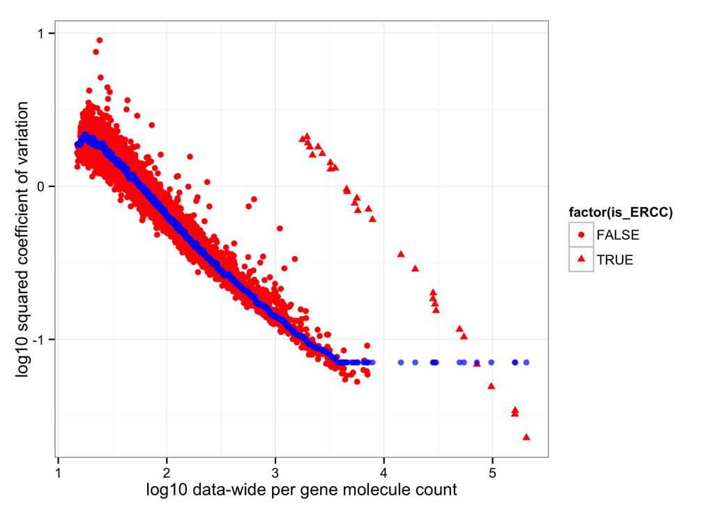

[figure not shown]

Compute adjusted coefficient of variation.

```r
# adjusted coefficient of variation on log10 scale
log10cv2_adj <-
  lapply(1:length(molecules_cv_batch), function(per_batch) {
    foo <- log10(molecules_cv_batch[[per_batch]]$cv^2) - roll_medians
    return(foo)
})
df_plot$log10cv2_adj <- do.call(c, log10cv2_adj)
df_plot$is_ERCC <- ( 1:dim(df_plot)[1] %in% grep("ERCC", rownames(df_plot)) )
```

Adjusted squared coefficient of variation versus log10 mean count (CPM corrected).

ERCC remain the outliers after substracting out rolling medians.

```r
ggplot( df_plot, aes(x = log10(mean), y = log10cv2_adj) ) +
  geom_point( aes(col = as.factor(batch), shape = factor(is_ERCC)), cex = .9 ) +
  facet_wrap( ~ batch) +
  labs(x = "log10(Mean CPM)", y = "log10(Adjusted Squared coefficient of variation")
```

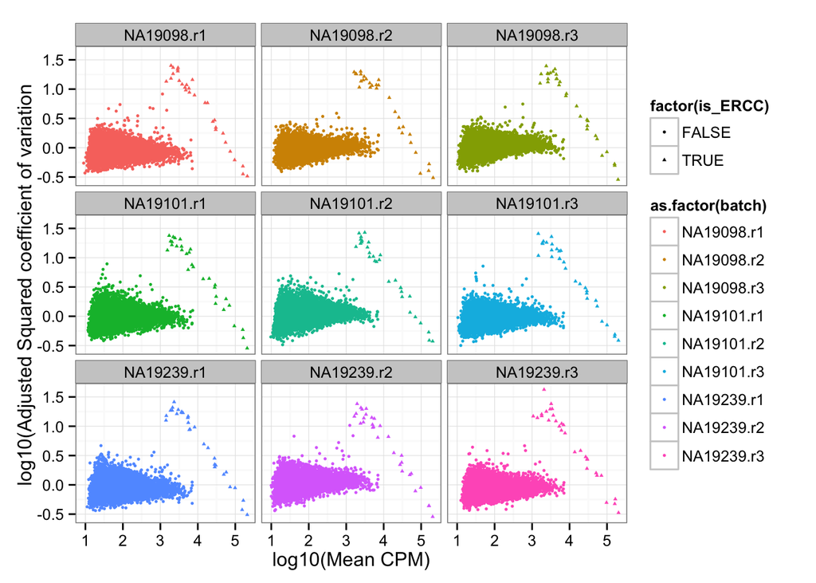

[figure not shown]

All genes: coefficient of variation after adjustment.

```r
ggplot(df_plot, aes(x= factor(batch), y = log10cv2_adj, fill = factor(batch) ) ) +
  geom_violin(alpha = .5) +
  geom_boxplot(alpha = .01, width = .2, position = position_dodge(width = .9)) +
  labs(xlab = "log10 adjusted Squared coefficient of variation") +
  ggtitle( "log10 CV^2 after adjustment" )
```

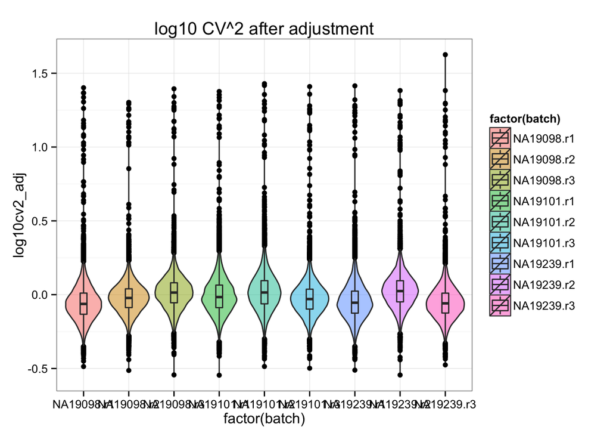

[figure not shown]

```r
  theme(axis.text.x = element_text(hjust=1, angle = 45))
```

[output not shown]

All genes: coefficient of variation before adjustment.

```r
ggplot(df_plot, aes(x= factor(batch), y = log10(cv^2), fill = factor(batch) ) ) +
  geom_violin(alpha = .5) +
  geom_boxplot(alpha = .01, width = .2, position = position_dodge(width = .9)) +
  labs(xlab = "log10 unadjusted Squared coefficient of variation") +
  ggtitle( "log10 CV^2 before adjustment" )
```

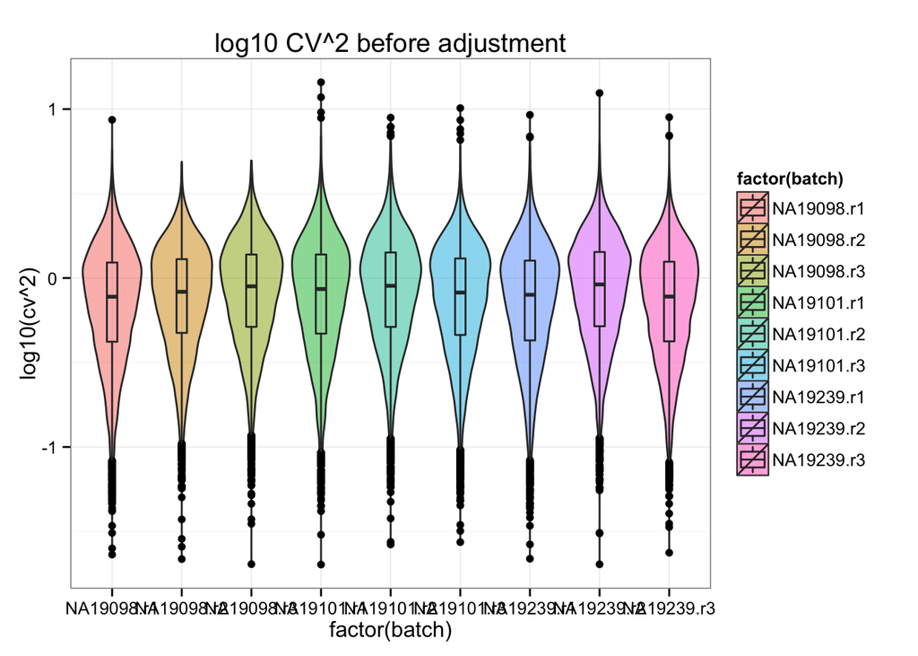

[figure not shown]

```r
  theme(axis.text.x = element_text(hjust=1, angle = 45))
```

[output not shown]

Endogeneous genes: coefficient of variation after adjustment.

```r
ggplot(df_plot[which(!df_plot$is_ERCC), ], aes(x= factor(batch), y = log10cv2_adj, fill = factor(batch) ) ) +
  geom_violin(alpha = .5) +
  geom_boxplot(alpha = .01, width = .2, position = position_dodge(width = .9)) +
  labs(xlab = "log10 adjusted Squared coefficient of variation") +
  ggtitle( "log10 CV^2 after adjustment w/o ERCC" )
```

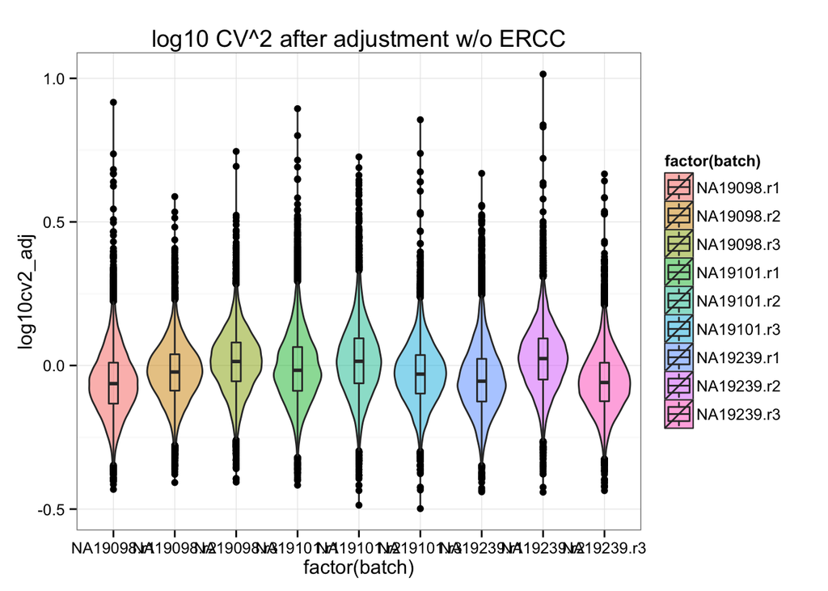

[figure not shown]

```r
  theme(axis.text.x = element_text(hjust=1, angle = 45))
```

[output not shown]

Endogeneous genes: coefficient of variation before adjustment.

```r
ggplot(df_plot[which(!df_plot$is_ERCC), ], aes(x= factor(batch), y = log10(cv^2), fill = factor(batch) ) ) +
  geom_violin(alpha = .5) +
  geom_boxplot(alpha = .01, width = .2, position = position_dodge(width = .9)) +
  labs(xlab = "log10 unadjusted Squared coefficient of variation") +
  ggtitle( "log10 CV^2 before adjustment w/o ERCC" )
```

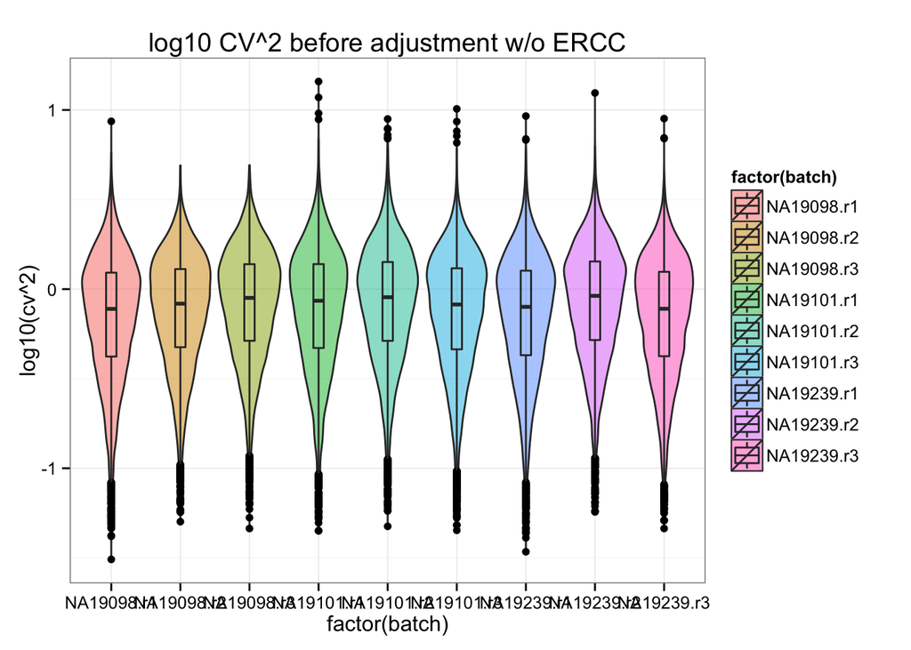

[figure not shown]

```r
  theme(axis.text.x = element_text(hjust=1, angle = 45))
```

[output not shown]